# FIT5197 2025 S2 Assignment - Covers the lecture and tutorial materials up to, and including, week 8

**SPECIAL NOTE:** Please refer to the assessment page for rules, general guidelines and marking rubrics of the assessment (the marking rubric for the kaggle competition part will be released near the deadline in the same page). Failure to comply with the provided information will result in a deduction of mark (e.g., late penalties) or breach of academic integrity.

**Mandatory Mathematics Interview (20%):**

To receive a grade for this assignment, you must complete a Mathematics Interview worth 20% of the assignment mark. The interview verifies that the work is your own and focuses on concepts used in the assignment. Students who do not attend will receive 0 for the assignment.

# Part 1 Point Estimation (30 marks)

**WARNING:** you should strictly follow the 3-steps strategy as detailed in question 2 of week 5 tutorial (or any answer formats presented in the Week 5 quiz) to answer for the questions that are related to MLE estimators presented in this part. Any deviations from the answer format might result in a loss of marks!

## Question 1 (7.5 marks)

Let $X\,{\sim}\,\mathcal{IG}\left(\theta: \left(\mu, \lambda\right)\right),\;\,\forall\, \mu>0 \text{ and } \lambda>0$. This means the random varible $X$ follows the **inverse Gaussian distribution** with the set $\left(\theta: \left(\mu, \lambda\right)\right)$ acting as the parameters of said distribution. Given that we observe a sample of size $n$ that is independently and identically distributed from this distribution ([i.i.d](https://en.wikipedia.org/wiki/Independent_and_identically_distributed_random_variables)), $\mathbf{x}=$ $\left(x_{1}, \ldots, x_{n}\right)$, please find the [maximum likelihood estimate](https://en.wikipedia.org/wiki/Maximum_likelihood_estimation) for $\mu$ and $\lambda$, that is $\mu_{\text{MLE}}$ and $\lambda_{\text{MLE}}$. The probability density function (**PDF**) is as follows:

$$ f(x \mid \mu, \lambda)=\left\{\begin{array}{cc} \left(\frac{\lambda}{2 \pi x^{3}}\right)^{1 / 2} e^{\frac{-\lambda(x-\mu)^{2}}{2 \mu^{2} x}}, & x>0 \\ 0, & x \leq 0 \end{array}\right. $$

### ANSWER

ANSWER

Likelihood Function For independent data $x_1, x_2, \ldots, x_n$ from the inverse Gaussian distribution $\operatorname{IG}(\mu, \lambda)$, the joint likelihood is:

$$ L(\mu, \lambda)=\prod_{i=1}^n f\left(x_i \mid \mu, \lambda\right)=\prod_{i=1}^n\left(\frac{\lambda}{2 \pi x_i^3}\right)^{\frac{1}{2}} \exp \left(-\frac{\lambda\left(x_i-\mu\right)^2}{2 \mu^2 x_i}\right) $$

Negative Log-Likelihood with "log"

$$ \begin{aligned} \ell(\mu, \lambda) & =-\log L(\mu, \lambda) \\ & =-\sum_{i=1}^n\left[\frac{1}{2} \log \left(\frac{\lambda}{2 \pi x_i^3}\right)-\frac{\lambda\left(x_i-\mu\right)^2}{2 \mu^2 x_i}\right] \\ & =-\frac{n}{2} \log \lambda+\frac{n}{2} \log (2 \pi)+\frac{3}{2} \sum_{i=1}^n \log x_i+\frac{\lambda}{2} \sum_{i=1}^n \frac{\left(x_i-\mu\right)^2}{\mu^2 x_i} \end{aligned} $$

Differentiate the Negative Log-Likelihood w.r.t. $\mu$ and Find $\mu_{M L E}$ Deriving $\ell(\mu, \lambda)$ with respect to $\mu$ :

$$ \frac{\partial \ell}{\partial \mu}=\frac{\lambda}{2} \sum_{i=1}^{\mathrm{n}} \frac{\partial}{\partial \mu}\left(\frac{\left(x_i-\mu\right)^2}{\mu^2 x_i}\right) $$

Calculating the derivative inside the sum step-by-step:

$$ \frac{\partial}{\partial \mu}\left(\frac{\left(x_i-\mu\right)^2}{\mu^2 x_i}\right) $$

$$ \frac{d}{d \mu}\left(\frac{u}{v}\right)=\frac{u^{\prime} v-u v^{\prime}}{v^2} $$

- $u^{\prime}=\frac{d}{d \mu}\left(x_i-\mu\right)^2=2\left(x_i-\mu\right)(-1)=-2\left(x_i-\mu\right)$
- $v^{\prime}=\frac{d}{d \mu}\left(\mu^2 x_i\right)=2 \mu x_i$

Plugging these we get

$$ \frac{\partial}{\partial \mu}\left(\frac{\left(x_i-\mu\right)^2}{\mu^2 x_i}\right)=\frac{-2\left(x_i-\mu\right) \cdot\left(\mu^2 x_i\right)-\left(x_i-\mu\right)^2 \cdot 2 \mu x_i}{\left(\mu^2 x_i\right)^2} $$

Simplifying the numerator we get

$$ -2\left(x_i-\mu\right) \mu^2 x_i-2\left(x_i-\mu\right)^2 \mu x_i=-2 x_i \mu^2\left(x_i-\mu\right)-2 x_i \mu\left(x_i-\mu\right)^2 $$

So the full simplified answer is:

$$ \frac{\partial}{\partial \mu}\left(\frac{\left(x_i-\mu\right)^2}{\mu^2 x_i}\right)=\frac{-2 x_i \mu^2\left(x_i-\mu\right)-2 x_i \mu\left(x_i-\mu\right)^2}{\left(\mu^2 x_i\right)^2} $$

WKT

$$ \frac{\partial \ell}{\partial \mu}=\frac{\lambda}{2} \sum_{i=1}^{\mathrm{n}} \frac{\partial}{\partial \mu}\left(\frac{\left(x_i-\mu\right)^2}{\mu^2 x_i}\right) $$

From $$ \frac{\partial}{\partial \mu}\left(\frac{\left(x_i-\mu\right)^2}{\mu^2 x_i}\right)=\frac{-2 x_i \mu^2\left(x_i-\mu\right)-2 x_i \mu\left(x_i-\mu\right)^2}{\left(\mu^2 x_i\right)^2} $$

Factor out $-2 x_i$ from the numerator:

$$ -2 x_i\left[\mu^2\left(x_i-\mu\right)+\mu\left(x_i-\mu\right)^2\right] $$

Expand $\mu\left(x_i-\mu\right)^2=\mu\left(x_i^2-2 x_i \mu+\mu^2\right)=\mu x_i^2-2 \mu^2 x_i+\mu^3$

Now add $\mu^2\left(x_i-\mu\right)$ :

$$ \mu^2 x_i-\mu^3+\mu x_i^2-2 \mu^2 x_i+\mu^3=\left(\mu^2 x_i-2 \mu^2 x_i\right)+\left(\mu x_i^2\right)+\left(-\mu^3+\mu^3\right)=-\mu^2 x_i+\mu x_i^2 $$

So, the numerator becomes:

$$ -2 x_i\left[-\mu^2 x_i+\mu x_i^2\right]=2 x_i\left[\mu^2 x_i-\mu x_i^2\right]=2 x_i^2 \mu^2-2 x_i^3 \mu $$

Thus,

$$ \frac{\partial}{\partial \mu}\left(\frac{\left(x_i-\mu\right)^2}{\mu^2 x_i}\right)=\frac{2 x_i^2 \mu^2-2 x_i^3 \mu}{\left(\mu^2 x_i\right)^2} $$

Now, sum over $i$, and include the prefactor $\frac{\lambda}{2}$ : Final Step

$$ \frac{\partial \ell}{\partial \mu}=\frac{\lambda}{2} \sum_{i=1}^n \frac{2 x_i^2 \mu^2-2 x_i^3 \mu}{\left(\mu^2 x_i\right)^2}=\lambda \sum_{i=1}^n \frac{x_i^2 \mu^2-x_i^3 \mu}{\mu^4 x_i^2} $$

Simplifying denominator and numerator by dividing numerator and denominator by $x_i^2$ (since $x_i \neq 0$ ):

$$ =\lambda \sum_{i=1}^n \frac{\mu^2-x_i \mu}{\mu^4} $$

Therefore,

$$ \frac{\partial \ell}{\partial \mu}=\lambda \sum_{i=1}^n \frac{\mu-x_i}{\mu^3} $$

Set $\frac{\partial \ell}{\partial \mu}=0$ and by algebraic manipulation, the maximizing estimate is:

$$ \frac{\partial \ell}{\partial \mu}=\lambda \sum_{i=1}^n \frac{\mu-x_i}{\mu^3}=0 $$

Since $\lambda$ and $\mu^3$ (assuming $\mu \neq 0$ ) are not zero, divide both sides by $\lambda$ :

$$ \sum_{i=1}^n\left(\mu-x_i\right)=0 $$

Expanding the sum:

$$ \begin{gathered} \sum_{i=1}^n \mu-\sum_{i=1}^n x_i=0 \\ n \mu-\sum_{i=1}^n x_i=0 \\ n \mu=\sum_{i=1}^n x_i \\ \mu=\frac{1}{n} \sum_{i=1}^n x_i \end{gathered} $$

So, the maximum likelihood estimate (MLE) for $\mu$ is simply the sample mean:

$$ \hat\mu_{\text {MLE }}=\frac{1}{n} \sum_{i=1}^n x_i $$

Differentiate the Negative Log-Likelihood w.r.t. $\lambda$ and Find $\lambda_{M L E}$ Deriving $\ell(\mu, \lambda)$ with respect to $\lambda$ :

$$ \ell(\mu, \lambda)=-\frac{n}{2} \log \lambda+\frac{n}{2} \log (2 \pi)+\frac{3}{2} \sum_{i=1}^n \log x_i+\frac{\lambda}{2} \sum_{i=1}^n \frac{\left(x_i-\mu\right)^2}{\mu^2 x_i} $$

The terms involving $\lambda$ are:

$$ -\frac{n}{2} \log \lambda+\frac{\lambda}{2} \sum_{i=1}^n \frac{\left(x_i-\mu\right)^2}{\mu^2 x_i} $$

Differentlating with respect to $\lambda$ and setting to zero, we get

$$ \frac{\partial l}{\partial \lambda}=-\frac{n}{2 \lambda}+\frac{1}{2} \sum_{i=1}^n \frac{\left(x_i-\mu\right)^2}{\mu^2 x_i}=0 $$

Multiply both sides by 2 :

$$ \begin{gathered} -\frac{n}{\lambda}+\sum_{i=1}^n \frac{\left(x_i-\mu\right)^2}{\mu^2 x_i}=0 \\ \frac{n}{\lambda}=\sum_{i=1}^n \frac{\left(x_i-\mu\right)^2}{\mu^2 x_i} \\ \lambda=\frac{n}{\sum_{i=1}^n \frac{\left(x_i-\mu\right)^2}{\mu^2 x_i}} \end{gathered} $$

Substitute the MLE for $\mu$ You previously found $\mu_{M L E}=\bar{x}=\frac{1}{n} \sum_{i=1}^n x_i$. Substitute this into the expression for $\lambda$, and simplify the denominator: Notice that

$$ \sum_{i=1}^n \frac{\left(x_i-\bar{x}\right)^2}{\bar{x}^2 x_i}=\sum_{i=1}^n\left(\frac{x_i^2-2 x_i \bar{x}+\bar{x}^2}{\bar{x}^2 x_i}\right) $$

Split the terms

$$ \frac{x_i^2}{\bar{x}^2 x_i}=\frac{x_i}{\bar{x}^2} \quad \frac{-2 x_i \bar{x}}{\bar{x}^2 x_i}=\frac{-2}{\bar{x}} \quad \frac{\bar{x}^2}{\bar{x}^2 x_i}=\frac{1}{x_i} $$

Therefore,

$$ \sum_{i=1}^n \frac{x_i}{\bar{x}^2}-2 \frac{1}{\bar{x}}+\frac{1}{x_i} $$

$$ \sum_{i=1}^n \frac{\left(x_i-\bar{x}\right)^2}{\bar{x}^2 x_i}=\sum_{i=1}^n \frac{1}{x_i}-\frac{n}{\bar{x}} $$

Final Form for the MLE

$$ \hat{\lambda}_{M L E}=\frac{n}{\sum_{i=1}^n \frac{1}{x_i}-\frac{n}{x}} $$

Final Answer

$$ \begin{array}{r} \hat{\mu}_{M L E}=\bar{x}=\frac{1}{n} \sum_{i=1}^n x_i \\ \hat{\lambda}_{M L E}=\frac{n}{\sum_{i=1}^n \frac{1}{x_i}-\frac{n}{\bar{x}}} \end{array} $$

## Question 2 (7.5 marks)

Suppose that we know that the random variable $X{\,\sim\,}\mathcal{Dist}(\mu=\theta, \sigma^2=\theta^2)$ follows the PDF given below:

$$ \begin{equation} f\left(x|\theta\right)= \begin{cases} \frac{1}{\theta} \exp(-\frac{x}{\theta}) & x > 0 \\ 0 & \text{otherwise.} \end{cases} \end{equation} $$

Given a sample of $n$ [i.i.d](https://en.wikipedia.org/wiki/Independent_and_identically_distributed_random_variables) observations $\mathbf{x}=$ $\left(x_{1}, \ldots, x_{n}\right)$ from this distribution, please answer the following questions:

*(a)* Derive the MLE estimator for $\theta$, i.e., $\hat{\theta}_{\text{MLE}}$, and show that it is unbiased. [2.5 Marks]

*(b)* Find an estimator with better MSE (i.e smaller MSE) compared to the $\hat{\theta}_{\text{MLE}}$ obtained from (a). [5 Marks]

### ANSWER

### (a)

MLE Estimator Derivation

Likelihood Function Given the PDF:

$$ f(x \mid \theta)= \begin{cases}\frac{1}{\theta} \exp \left(-\frac{x}{\theta}\right), & x>0 \\ 0, & \text { otherwise }\end{cases} $$

The likelihood for i.i.d. sample $\mathbf{x}=\left(x_1, \ldots, x_n\right)$ is:

$$ L(\theta)=\prod_{i=1}^n \frac{1}{\theta} \exp \left(-\frac{x_i}{\theta}\right)=\frac{1}{\theta^n} \exp \left(-\frac{1}{\theta} \sum_{i=1}^n x_i\right) $$

Negative Log-Likelihood Taking the negative log of the likelihood:

$$ -\ell(\theta)=n \log \theta+\frac{1}{\theta} \sum_{i=1}^n x_i $$

Differentiate w.r.t. $\theta$

$$ \frac{d}{d \theta}(-\ell(\theta))=\frac{n}{\theta}-\frac{1}{\theta^2} \sum_{i=1}^n x_i $$

Set derivative to zero

$$ \frac{n}{\hat{\theta}}-\frac{1}{\hat{\theta}^2} \sum_{i=1}^n x_i=0 $$

Multiplying both sides by $\hat{\theta}^2$ :

$$ n \hat{\theta}-\sum_{i=1}^n x_i=0 $$

Solve for $\hat{\theta}$

$$ \hat{\theta}=\frac{1}{n} \sum_{i=1}^n x_i=\bar{x} $$

Proof of Unbiasedness Since $\mathbb{E}\left[X_i\right]=\theta$, it follows that:

$$ \mathbb{E}[\hat{\theta}]=\mathbb{E}[\bar{x}]=\theta $$

Hence, $\hat{\theta}$ is unbiased.

### (b)

Construction of an Improved Estimator with Smaller MSE

Variance of $\hat{\theta}$ Given the variance of each $X_i$ is $\theta^2$, the variance of the sample mean is:

$$ \operatorname{Var}(\hat{\theta})=\operatorname{Var}\left(\frac{1}{n} \sum_{i=1}^n x_i\right) $$

If you multiply a random variable by a constant, the variance is multiplied by the square of that constant. Here, the constant is $\frac{1}{n}$, so the variance is divided by $n^2$.

$$ =\frac{1}{n^2} \operatorname{Var}\left(\sum_{i=1}^n x_i\right) $$ $$ =\frac{1}{n^2} \sum_{i=1}^n \operatorname{Var}\left(x_i\right) $$

Every $ x_i $ has variance $\theta^2$, so you sum this up $n$ times, giving $ n\theta^2 $.

$$ =\frac{1}{n^2} \cdot n \theta^2 $$ $$ =\frac{\theta^2}{n} . $$

$$ \operatorname{Var}(\hat{\theta})=\operatorname{Var}(\bar{x})=\frac{\theta^2}{n} $$

Define a scaled estimator Consider:

$$ \tilde{\theta}=c \bar{x} $$

where $c$ is a scalar parameter.

$$ \mathbb{E}[\hat{\theta}]=c \mathbb{E}[\bar{x}]=c .\theta, $$ $$ \operatorname{Bias}(\bar{x})=\mathbb{E}[\bar{x}]-\theta $$ $$ \quad \operatorname{Bias}(\bar{\theta})=c \theta-\theta $$

Calculate MSE of $\tilde{\theta}$ MSE is:

$$ \begin{aligned} \operatorname{MSE}(\tilde{\theta}) & =\operatorname{Var}(\bar{\theta})+\operatorname{Bias}(\bar{\theta})^2 \\ & =c^2 \frac{\theta^2}{n}+(c \theta-\theta)^2 \end{aligned} $$ $$ =c^2 \frac{\theta^2}{n}+(c \theta-\theta)^2 $$

Expanding $(c \theta-\theta)^2$

$$ (c \theta-\theta)^2=[c \theta-1 \cdot \theta]^2=[\theta(c-1)]^2=\theta^2(c-1)^2 $$

Substituting it back, we get

$$ =c^2 \frac{\theta^2}{n}+\theta^2(c-1)^2 $$

Taking Out $\theta^2$, we get

$$ =\theta^2\left(\frac{c^2}{n}+(c-1)^2\right) $$

Therefore

$$ =\theta^2\left(\frac{c^2}{n}+(c-1)^2\right) $$

Minimize MSE w.r.t. $c$ Take derivative:

$$ \frac{d}{d c}\left(\frac{c^2}{n}+(c-1)^2\right)=\frac{2 c}{n}+2(c-1)=0 $$

Solving for $c$ :

$$ c\left(1+\frac{1}{n}\right)=1 \quad \Longrightarrow \quad c=\frac{n}{n+1} $$

Improved estimator and comparison of MSE The improved estimator is:

$$ \dot{\theta}=\frac{n}{n+1} \bar{x} $$

Computing its MSE:

$$ \operatorname{MSE}(\bar{\theta})=\theta^2\left(\frac{c^2}{n}+(c-1)^2\right)=\theta^2 \cdot \frac{1}{n+1}<\frac{\theta^2}{n}=\operatorname{MSE}(\hat{\theta}) $$

Therefore, $\tilde{\theta}$ has smaller mean squared error than the MLE $\hat{\theta}$.

## Question 3 (7.5 marks)

Suppose that we know that a random variable $X$ follows the distribution given below:

$$ f\left(x|\theta\right)= \frac{{2 \choose x}\theta^x\left(1-\theta\right)^{2-x}}{1-\left(1-\theta\right)^2}, \; x= \{1,2\} $$

Imagine that we observe a sample of $\textbf{n}$ [i.i.d](https://en.wikipedia.org/wiki/Independent_and_identically_distributed_random_variables) random varaibles $\mathbf{x}=$ $\left(x_{1}, \ldots, x_{n}\right)$ and want to model them using this distribution. Please use the concept of maximum likelihood to estimate for the parameter $\theta$.

### ANSWER

Likelihood Function Suppose $n_1$ values are $x=1, n_2$ values are $x=2$, so $n=n_1+n_2$. The likelihood is:

$$ L(\theta)=\prod_{i=1}^n f\left(x_i \mid \theta\right)=\frac{\theta^{n_1+2 n_2}(1-\theta)^{n_1}}{\left[1-(1-\theta)^2\right]^n} $$

Taking the Negative Log-Likelihood

$$ \ell(\theta)=-\log L(\theta)=-\left(n_1+2 n_2\right) \log \theta-n_1 \log (1-\theta)+n \log \left(1-(1-\theta)^2\right) . $$

The derivative with respect to $\theta$ is:

Lets first differentiate

$$ \frac{d}{d \theta} n \log \left(1-(1-\theta)^2\right) $$

Let's denote $g(\theta)=1-(1-\theta)^2=2 \theta-\theta^2$. So,

$$ \frac{d}{d \theta} n \log (g(\theta))=n \cdot \frac{1}{g(\theta)} \cdot g^{\prime}(\theta) $$

Compute $g^{\prime}(\theta)$ :

$$ g(\theta)=2 \theta-\theta^2 \Longrightarrow g^{\prime}(\theta)=2-2 \theta $$

So,

$$ \frac{d}{d \theta} n \log \left(2 \theta-\theta^2\right)=n \cdot \frac{2-2 \theta}{2 \theta-\theta^2}=n \cdot \frac{2(1-\theta)}{2 \theta-\theta^2} $$

Now differentiating

$$ -\left(n_1+2 n_2\right) \log \theta $$

$$ \frac{d}{d \theta}\left[-\left(n_1+2 n_2\right) \log \theta\right]=-\frac{n_1+2 n_2}{\theta} $$

Then differentiating

$$ -n_1 \log (1-\theta) $$

$$ \frac{d}{d \theta}\left[-n_1 \log (1-\theta)\right]=-n_1 \cdot \frac{-1}{1-\theta}=\frac{n_1}{1-\theta} $$

Collect and Combine: All pieces come together:

$$ \frac{d \ell}{d \theta}=n \frac{2(1-\theta)}{2 \theta-\theta^2}-\frac{n_1+2 n_2}{\theta}+\frac{n_1}{1-\theta} $$

$$ \frac{d \ell}{d \theta}=n \frac{2(1-\theta)}{2 \theta-\theta^2}-\frac{n_1+2 n_2}{\theta}+\frac{n_1}{1-\theta} $$

Setting to zero:

$$ n \frac{2(1-\theta)}{2 \theta-\theta^2}-\frac{n_1+2 n_2}{\theta}+\frac{n_1}{1-\theta}=0 $$

Multiplying both sides by $\theta(1-\theta)\left(2 \theta-\theta^2\right)$ to clear denominators

$$ n \cdot 2(1-\theta) \theta(1-\theta)-\left(n_1+2 n_2\right)(1-\theta)\left(2 \theta-\theta^2\right)+n_1 \theta\left(2 \theta-\theta^2\right)=0 $$

Expanding first term $(1-\theta) \theta(1-\theta)=(1-\theta)^2 \theta$ gives

$$ 2 n \cdot(1-\theta)^2 \theta=2 n \theta\left(1-2 \theta+\theta^2\right)=2 n \theta-4 n \theta^2+2 n \theta^3 $$

Expanding second term $(1-\theta)\left(2 \theta-\theta^2\right)$ gives

$$ (1-\theta)\left(2 \theta-\theta^2\right)=2 \theta-\theta^2-2 \theta^2+\theta^3=2 \theta-3 \theta^2+\theta^3 $$

Therefore,

$$ -\left(n_1+2 n_2\right)\left(2 \theta-3 \theta^2+\theta^3\right)=-\left(n_1+2 n_2\right) 2 \theta+\left(n_1+2 n_2\right) 3 \theta^2-\left(n_1+2 n_2\right) \theta^3 $$

Expanding third term $\theta\left(2 \theta-\theta^2\right)$ gives

$$ n_1 \theta\left(2 \theta-\theta^2\right)=n_1\left(2 \theta^2-\theta^3\right) $$

Combining all the above terms

- $\theta^3$ terms:
- From first term: $+2 n \theta^3$
- From second term: $-\left(n_1+2 n_2\right) \theta^3$
- From third term $-n_1 \theta^3$

Therefore $\theta^3$ Coefficients are: $2 n \theta^3-\left(n_1+2 n_2\right) \theta^3-n_1 \theta^3$

- $\theta^2$ terms:
- From first term: $-4 n \theta^2$
- From second term: $+3\left(n_1+2 n_2\right) \theta^2$
- From third term: $+2 n_1 \theta^2$

Therefore $\theta^2$ Coefficients are: $-4 n \theta^2+3\left(n_1+2 n_2\right) \theta^2+2 n_1 \theta^2$

- $\theta$ terms:
- From first term: $+2 n \theta$
- From second term: $-2\left(n_1+2 n_2\right) \theta$

Therefore $\theta$ Coefficients are: $2 n \theta-2\left(n_1+2 n_2\right) \theta$

Substituting $n=n_1+n_2$ in $\theta^3$ coefficient:

$$ 2 n-n_1-2 n_2-n_1=\left(2 n-2 n_1-2 n_2\right)=2\left(n_1+n_2\right)-2 n_1-2 n_2=0 $$

So $\theta^3$ term vanishes!

Therefore, $\theta^2$ coefficient:

$$ -4 n+3\left(n_1+2 n_2\right)+2 n_1=-4\left(n_1+n_2\right)+3 n_1+6 n_2+2 n_1=\left(-4 n_1+3 n_1+2 n_1\right)+(-\left.4 n_2+6 n_2\right)=n_1+2 n_2 $$ $\theta$ coefficient:

$$ 2 n-2\left(n_1+2 n_2\right)=2\left(n_1+n_2\right)-2 n_1-4 n_2=2 n_1+2 n_2-2 n_1-4 n_2=-2 n_2 $$

The Quadratic Equation is $$ ({n_1+2 n_2})\theta^2-{2 n_2}\theta=0 $$

$$ ({n_1+2 n_2})\theta^2 = {2 n_2}\theta $$

Dividing $\theta$ on both sides, we get

Final Answer

$$ {\theta}=\frac{2 n_2}{n_1+2 n_2} $$

## Question 4 (7.5 marks)

Suppose that we know that the random variable $X$ follows the PDF given below:

$$ \begin{equation} f\left(x|\theta\right)= \begin{cases} e^{-(x-\theta)} & x\geq\theta \\ 0 & \text{otherwise.} \end{cases} \end{equation} $$

Given a sample of $n$ [i.i.d](https://en.wikipedia.org/wiki/Independent_and_identically_distributed_random_variables) observations $\mathbf{x}=$ $\left(x_{1}, \ldots, x_{n}\right)$ from this distribution, please answer the following questions:

**(a)** Derive the MLE estimator for $\theta$, i.e., $\hat{\theta}_{\text{MLE}}$. [4.5 Marks]

**(b)** Show that the estimator $\hat{\theta} = \overline{X} - 1$ (where $\overline{X} = \frac{1}{n}\sum_{i=1}^n X_i$) is an unbiased and consistent estimator for the given distribution. [3 Marks]

### ANSWER

### (a)

Given the PDF is,

$$ f(x ; \theta)= \begin{cases}e^{-(x-\theta)} & x \geq \theta \\ 0 & \text { otherwise }\end{cases} $$

For i.i.d. observations $x_1, x_2, \ldots, x_n$ :

$$ L(\theta)=\prod_{i=1}^n f\left(x_i ; \theta\right)=\prod_{i=1}^n e^{-\left(x_i-\theta\right)} \cdot I\left(x_i \geq \theta\right) $$

where $I\left(x_i \geq \theta\right)$ is the indicator function, 1 if true, 0 otherwise.

The (natural) log-likelihood is:

$$ \ell(\theta)=\log L(\theta)=\sum_{i=1}^n \log \left[e^{-\left(x_i-\theta\right)}\right]=\sum_{i=1}^n\left[-\left(x_i-\theta\right)\right] $$

Thus,

$$ \ell(\theta)=-\sum_{i=1}^n x_i+n \theta $$

for $\theta \leq \min x_i$, and $-\infty$ otherwise.

The negative log-likelihood is:

$$ -\ell(\theta)=\sum_{i=1}^n x_i-n \theta $$

for $\theta \leq \min x_i$.

Because $\sum_{i=1}^n x_i$ is constant, $-n \theta$ is minimized for the largest feasible $\theta$. But, by the support constraint, $\theta \leq \min \left(x_1, \ldots, x_n\right)$. Thus, the negative log-likelihood is minimized when:

$$ \theta=\min \left(x_1, x_2, \ldots, x_n\right) $$

So, the MLE for $\boldsymbol{\theta}$ using the negative log-likelihood is:

$$ \hat{\theta}_{M L E}=\min \left(x_1, x_2, \ldots, x_n\right) $$

### (b)

Given:

$$ f(x \mid \theta)= \begin{cases}e^{-(x-\theta)} & x \geq \theta \\ 0 & \text { otherwise }\end{cases} $$

Let

$$ Y=X-\theta $$

This implies that

$$ Y \sim \text { Exponential }(1), \quad f_Y(y)=e^{-y}, \quad y \geq 0 $$

Writing $\bar{X}$ in terms of $\bar{Y}$ The sample mean is:

$$ \bar{X}=\frac{1}{n} \sum_{i=1}^n X_i=\frac{1}{n} \sum_{i=1}^n\left(Y_i+\theta\right)=\bar{Y}+\theta $$

where

$$ \bar{Y}=\frac{1}{n} \sum_{i=1}^n Y_i $$

Calculate the expectation $E[\hat{\theta}]$ The estimator is defined as:

$$ \hat{\theta}=\bar{X}-1=(\bar{Y}+\theta)-1=\bar{Y}+(\theta-1) $$

Use the linearity of expectation:

$$ E[\hat{\theta}]=E[\bar{Y}]+\theta-1 $$

Since all $Y_i$ are i.i.d. with exponential(1):

$$ E[\bar{Y}]=E\left[Y_i\right]=1 $$

Therefore,

$$ E[\hat{\theta}]=1+\theta-1=\theta $$

So, $\hat{\theta}$ is unbiased because its expectation equals $\hat{\theta}$. Step 4: Show consistency $\hat{\theta} \xrightarrow{p} \theta$ By the Law of Large Numbers:

$$ \bar{Y} \xrightarrow{P} E[Y]=1 \quad \text { as } n \rightarrow \infty $$

Therefore,

$$ \hat{\theta}=\bar{Y}+(\theta-1) \xrightarrow{p} 1+(\theta-1)=\theta $$

So, $\hat{\theta}$ is consistent.

# Part 2 Confidence Interval Estimation & Central Limit Theorem (30 marks)

**WARNING:** If it is not explicitly stated, please assume the 95% confidence or 5% significant level.

## Question 1 (5 marks)

The [SETU](https://www.monash.edu/ups/setu) score of FIT units is known to follow a $\mathcal{N}(\mu=4$, $\sigma^2=0.25)$ distribution. You take a sample of the units and check their last semester's SETU. How many units do you have to sample to have a 95% confidence interval for $\mu$ with width 0.1?

### ANSWER

Given The SETU score is distributed as:

$$ X \sim \mathcal{N}\left(\mu=4, \sigma^2=0.25\right) $$

where

$$ \sigma=\sqrt{0.25}=0.5 $$

Confidence Interval A 95% confidence interval for $\mu$ is given by

$$ \bar{X} \pm z_{\alpha / 2} \frac{\sigma}{\sqrt{n}} $$

where

- $z_{\alpha / 2}=z_{0.025} \approx 1.96$ for $95 \%$ confidence
- $n$ is the sample size

The width of this confidence interval is

$$ \text { Width }=2 \times z_{\alpha / 2} \times \frac{\sigma}{\sqrt{n}} $$

Setting the interval width to 0.1

$$ 0.1=2 \times 1.96 \times \frac{0.5}{\sqrt{n}} $$

Simplifying numerator

$$ 1.96=2 \times 1.96 \times 0.5 $$

So,

$$ 0.1=\frac{1.96}{\sqrt{n}} $$

Multiplying both sides by $\sqrt{n}$

$$ 0.1 \times \sqrt{n}=1.96 $$

Solving for $\sqrt{n}$

$$ \sqrt{n}=\frac{1.96}{0.1}=19.6 $$

Squaring both sides

$$ n=(19.6)^2=384.16 $$

Rounding up to nearest whole number:

$$ n=385 $$

Final Answer: To achieve a $95 \%$ confidence interval width of 0.1 for the mean SETU score, you must sample at least 385 units.

## Question 2 (5 marks)

You do a poll to see what fraction $p$ of the students participated in the FIT5197 SETU survey. You then take the average frequency of all surveyed people as an estimate $\hat p$ for $p$. Now it is necessary to ensure that there is at least $99\%$ certainty that the difference between the surveyed rate $\hat p$ and the actual rate $p$ is not more than $5\%$. At least how many people should take the survey?

### ANSWER

Let $n$ be the sample size. The sample proportion $\hat{p}$ estimates the true proportion $p$. For large samples, the sampling distribution of $\hat{p}$ is approximately normal with mean $p$ and variance $\frac{p(1-p)}{n}$.

The requirement is:

$$ P(|\hat{p}-p| \leq 0.05) \geq 0.99 $$

For a normal distribution, the confidence interval at level $1-\alpha$ is

$$ \hat{p} \pm z_{\alpha / 2} \sqrt{\frac{p(1-p)}{n}} $$

Where $z_{\alpha / 2}$ is the critical value from the standard normal table for confidence level $1-\alpha$. For $99 \%$ confidence, $z_{\alpha / 2}=2.576$.

We want the margin of error to be no more than 0.05

$$ z_{\alpha / 2} \sqrt{\frac{p(1-p)}{n}} \leq 0.05 $$

Solving for n,

$$ \begin{gathered} 2.576 \sqrt{\frac{p(1-p)}{n}} \leq 0.05 \\ \sqrt{\frac{p(1-p)}{n}} \leq \frac{0.05}{2.576} \\ \frac{p(1-p)}{n} \leq\left(\frac{0.05}{2.576}\right)^2 \\ n \geq \frac{p(1-p)}{\left(\frac{0.05}{2.576}\right)^2} \end{gathered} $$

Since $\boldsymbol{p}$ is unknown, use the maximum possible value, which occurs at $\boldsymbol{p}=0.5$ :

$$ p(1-p) \leq 0.25 $$

Substitute $p(1-p)=0.25$ :

$$ n \geq \frac{0.25}{\left(\frac{0.05}{2.576}\right)^2} $$

Calculate denominator:

$$ \begin{gathered} \frac{0.05}{2.576}=0.0194 \\ (0.0194)^2=0.000376 \\ n \geq \frac{0.25}{0.000376} \approx 664.9 \end{gathered} $$

Final Answer At least 665 people should take the survey to ensure, with $99 \%$ confidence, that the error is less than $5 \%$.

## Question 3 (5 marks)

Suppose you repeated the above polling process multiple times and obtained $100$ confidence intervals, each with confidence level of $99\%$. About how many of them would you expect to be "wrong"? That is, how many of them would not actually contain the parameter being estimated? Should you be surprised if $4$ of them are wrong?

### ANSWER

Given

- 100 independent $99 \%$ confidence intervals
- Each interval contains the true parameter with probability 0.99 , and misses it with probability 0.01
- Observed: 4 intervals are wrong (do not contain the true parameter)

Binomial Model Let $X$ be the number of wrong (missed) intervals out of 100

$$ X \sim \operatorname{Binomial}(n=100, p=0.01) $$

We're interested in

- $\mathbb{E}[X]$ : Expected wrong intervals
- $P(X \geq 4)$ : Probability at least 4 intervals are wrong

Expected Number of Wrong Intervals

$$ \mathbb{E}[X]=n \times p=100 \times 0.01=1 $$

So, on average, 1 out of 100 intervals is expected not to contain the parameter. Probability of $\geq 4$ Wrong Intervals First, we compute $P(X \leq 3)$ :

$$ P(X \leq 3)=P(X=0)+P(X=1)+P(X=2)+P(X=3) $$

With

$$ P(X=k)=\binom{100}{k}(0.01)^k(0.99)^{100-k} $$

We compute each term:

$$ \begin{aligned} & P(X=0)=(0.99)^{100} \approx 0.366 \\ & P(X=1)=100 \times 0.01 \times(0.99)^{99} \approx 0.370 \\ & P(X=2)=\frac{100 \times 99}{2} \times(0.01)^2 \times(0.99)^{98} \approx 0.185 \\ & P(X=3)=\frac{100 \times 99 \times 98}{6} \times(0.01)^3 \times(0.99)^{97} \approx 0.061 \end{aligned} $$

The Sum is $$ P(X \leq 3) \approx 0.366+0.370+0.185+0.061=0.982 $$

Thus, the probability of getting at least 4 wrong

$$ P(X \geq 4)=1-P(X \leq 3)=1-0.982=0.018 $$

Interpretation

- Expected wrong: 1 interval.
- Probability of 4 or more being wrong: 0.018 or $1.8 \%$.

This event is uncommon but not impossible. You would usually expect $0,1,2$, or 3 wrong; 4 wrong intervals is rare at the $99 \%$ confidence level, but can still happen by chance.

## Question 4 (5 marks)

Consider the random variable $X$ following the Bernoulli distribution with a parameter $\theta$, i.e., $X\sim \text{Be}(\theta)$, where $\theta=0.9$. Given that you collect $n$ random variable $X_1, X_2,\ldots, X_n$. Calculate the smallest sample size, ${n}$, you have to observe to guarantee that

$$ P\left(\left|\frac{\sum_1^n X_i}{n} - \theta \right| >0.01\right) < 0.1. $$

### ANSWER

Given

$$ \bar{X}_n=\frac{1}{n} \sum_{i=1}^n X_i $$

approximately follows a normal distribution:

$$ \bar{X}_n \sim N\left(\theta, \frac{\theta(1-\theta)}{n}\right) $$

where $\theta=0.9$ is the parameter of the Bernoulli distribution. Distribution of the sample mean

$$ \bar{X}_n \approx N\left(0.9, \frac{0.9 \times 0.1}{n}\right)=N\left(0.9, \frac{0.09}{n}\right) . $$

Probability constraint We want

$$ P\left(\left|\bar{X}_n-0.9\right|>0.01\right)<0.1 $$

By the CLT approximation,

$$ P\left(\left|\bar{X}_n-0.9\right|>0.01\right)=P\left(\left|\frac{\bar{X}_n-0.9}{\sqrt{0.09 / n}}\right|>\frac{0.01}{\sqrt{0.09 / n}}\right) . $$

WKT

$$ Z=\frac{\bar{X}_n-\mu}{Std(\bar{X}_n)} = \frac{\bar{X}_n-\theta}{\sqrt{Var(\bar{X}_n)}} $$

Set

$$ Z=\frac{\bar{X}_n-0.9}{\sqrt{0.09 / n}} \sim N(0,1) . $$

Then the probability becomes

$$ P(|Z|>z)<0.1, $$

where

$$ z=\frac{0.01}{\sqrt{0.09 / n}}=\frac{0.01}{0.3 / \sqrt{n}}=\frac{0.01 \sqrt{n}}{0.3}=\frac{\sqrt{n}}{30} $$

Critical value ( z ) for the normal distribution The two-sided probability is

$$ P(|Z|>z)=2 \Phi(-z)<0.1 $$

where $\Phi$ is the standard normal CDF. This implies

$$ \Phi(-z)<0.05 \Longrightarrow \Phi(z)>0.95 . $$

From the standard normal table,

$$ z_{0.95} \approx 1.645 . $$

Solving for ( n ) Set

$$ \frac{\sqrt{n}}{30}=z_{0.95}=1.645 \Longrightarrow \sqrt{n}=1.645 \times 30=49.35 . $$

Squaring both sides,

$$ n=49.35^2=2435.7 $$

Final answer The smallest integer ( $n$ ) satisfying the condition is

$$ n=2436 $$

This means observing at least 2436 samples from the Bernoulli $(\theta=0.9)$ distribution is required to guarantee

$$ P\left(\left|\frac{\sum_{i=1}^n X_i}{n}-0.9\right|>0.01\right)<0.1 $$

based on the Normal approximation from the Central Limit Theorem.

## Question 5 (5 Marks)

The error for the production of a machine is uniformly distribute over [-0.75, 0.75] unit. Assuming that there are 100 machines working at the same time, approximate the probability that the final production differ from the exact production by more than 4.5 unit?

### ANSWER

Let $X_i=$ error from machine $i, X_i \sim$ Uniform $(-0.75,0.75)$.

$S_{100}=X_1+X_2+\ldots+X_{100}$ is the total error.

We want to calculate $P\left(\left|S_{100}\right|>4.5\right)$.

For $X_i \sim \operatorname{Uniform}(a, b)$

Mean: $\mu=\frac{a+b}{2}$

Variance: $\sigma^2=\frac{(b-a)^2}{12}$

Given: $a=-0.75, b=0.75$

$\mu=\frac{-0.75+0.75}{2}=0$

$b-a=0.75-(-0.75)=1.5$

$\sigma^2=\frac{1.5^2}{12}=\frac{2.25}{12}=0.1875$

For independent variables, $E\left[S_{100}\right]=100 \times 0=0$.

$\operatorname{Var}\left[S_{100}\right]=100 \times 0.1875=18.75$.

Therefore, $S_{100} \sim N(0,18.75)$ approximately (by Central Limit Theorem).

So, $P\left(\left|S_{100}\right|>4.5\right)$. Standardize using the normal approximation:

$$ Z=\frac{S_{100}-0}{\sqrt{18.75}} $$

The event:

$$ \left|S_{100}\right|>4.5 \longleftrightarrow|Z|>\frac{4.5}{\sqrt{18.75}} $$

$\sqrt{18.75} \approx 4.3301$

Therefore, $\frac{4.5}{4.3301} \approx 1.039$

So. $|Z|>1.039$.

When we see $P(|Z|>a)$, we are looking for the probability that a standard normal variable is either greater than $a$ or less than $-a$. In symbols:

$$ P(|Z|>a)=P(Z<-a)+P(Z>a) $$

The standard normal distribution (the bell curve) is symmetrical about zero. This means that

$$ P(Z<-a)=P(Z>a) $$

So, instead of calculating both sides, we can just double it:

$$ P(|Z|>a)=2 \times P(Z>a) $$

Plugging into $\alpha=1.039$ :

$$ P(|Z|>1.039)=2 \times P(Z>1.039) $$

- $P(|Z|>1.039)=2 \times P(Z>1.039)$

From standard normal tables:

$$ P(Z<1.039) \approx 0.8506 $$

$$ P(Z>1.039)=1-P(Z<1.039)=1-0.8506 \approx 0.1494 $$

So,

$$ P\left(\left|S_{100}\right|>4.5\right) \approx 2 \times 0.1495=0.299 $$

Therefore, The approximate probability is 0.30 (rounded)

## Question 6 (5 Marks)

Let $X_{1}, X_{2}, \ldots, X_{n}$ be a random sample from a Poisson distribution with mean $\lambda .$ Thus, $Y=\sum_{i=1}^{n} X_{i}$ has a Poisson distribution with mean $n \lambda .$ Moreover, by the Central limit Theorem, $\bar{X}=Y / n$ has, approximately, a Normal $(\lambda, \lambda / n)$ distribution for large $n$. Show that for large values of $n,$ the distribution of $$ 2 \sqrt{n}\left(\sqrt{\frac{Y}{n}}-\sqrt{\lambda}\right) $$ is independent of $\lambda$.

# Part 3 Hypothesis Testing (15 marks)

## Question 1 (7.5 marks)

As a motivation for students to attend the tutorial, Levin is offering a lot of hampers this semester. He has designed a spinning wheel (This is an example https://spinnerwheel.com/) where there are four choices on it: "Hamper A", "Hamper B", "Hamper C", and "Better Luck Next Time". These choices are evenly distributed on the wheel. If a student completes the attendance form for one of the tutorials, they will get a chance to spin the wheel.

As a hard-working student yourself, you have earned 12 chances at the end of the semester. When you finished your spins, the result showed {"N", "A", "N", "N", "B", "C", "N", "N", "N", "A", "A", "N"} ("A","B" and "C" denote three hampers respectively, while "N" denotes "Better Luck Next Time"). You are shocked by the result and feel the game might be faulty. Before questioning Levin, you would like to perform a hypothesis test to check whether you are really unlucky or has Levin secretly done something that had influenced the probability of winning or not. State your hypothesis, perform the test and interpret the result.

### ANSWER

$$ H_0: \theta=0.25 $$

$$ H_A: \theta>0.25 $$

Count the number of 'N's in your results: {"N", "A", "N", "N", "B", "C", "N", "N", "N", "A", "A", "N"}

Number of "N" outcomes = 7 Sample size $n=12$ Observed proportion:

$$ \hat{p}=\frac{7}{12}=0.5833 $$

Formula for $\boldsymbol{Z}$ :

$$ Z=\frac{\hat{p}-p_0}{\sqrt{\frac{p_0\left(1-p_0\right)}{n}}} $$

Substituting values, we get

$$ Z=\frac{0.5833-0.25}{\sqrt{\frac{0.25 \times(1-0.25)}{12}}}=\frac{0.3333}{\sqrt{\frac{0.25 \times 0.75}{12}}}=\frac{0.3333}{\sqrt{\frac{0.1875}{12}}}=\frac{0.3333}{\sqrt{0.015625}}=\frac{0.3333}{0.125}=2.6664 $$

To find $P(Z>2.6664)$,

$$ P(Z>2.6664)=1-P(Z \leq 2.6664) $$

From a $Z$-table, $P(Z \leq 2.6664)$ $\approx 0.9962$ .

So,

$$ P(Z>2.6664)=1-0.9962=0.0038 $$

Using standard normal distribution tables or software:

$$ P=2 \times P(Z>2.6664) $$

The probability $P(Z>2.6664)$ $\approx 0.0038$ .

Therefore,

$$ P=2 \times 0.0038=0.0076 $$

Typically, $\alpha=0.05$.

Since $P$ $= 0 . 0 0 7 6 < 0 . 0 5$, we reject the null hypothesis.

This means there is strong evidence that the probability of "N" is different from 0.25

Therefore, the wheel is biased toward "N".

## Question 2 (7.5 marks)

The operation team of a retailer is about to report the performance of year 2022. As the data analyst, your job entails reviewing the reports provided by the team. One of the reports regarding membership subscription looks suspicous to you. In this report, they compared the amount of money spent by the members against the non-members over the year. The methodology is that they randomly selected 20 customers and compared their spending before and after becoming a member.

The average spending before becoming a member is $\$88.5$ per week with a standard deviation of $\$11.2$. The average after becoming a member is $\$105$ per week with a standard deviation of $\$15$. In the report, the retailer claimed that after becoming a member, customers tend to spend $10\%$ more than before on average.

As a statistician, you decide to perform a hypothesis test to verify the veracity of this claim. State your hypothesis, perform the test and interpret the result. Additionally, please suggest another methodology to compare member vs non-member.

### ANSWER

$$ H_0: \theta=8.85 $$

$$ H_A: \theta>8.85 $$

Mean spending after: 105

Mean before: 88.5

$$ \bar{X}=105-88.5=16.5 $$

We do not have the raw paired data or correlation. Therefore, Estimating using $S=\sqrt{\left(s_{\text {after }}^2+s_{\text {before }}^2\right)}$ :

$$ S=\sqrt{\left(15^2+11.2^2\right)}=\sqrt{225+125.44}=\sqrt{350.44} \approx 18.72 $$

Therefore,

$$ t_{n-1}=\frac{\bar{X}-\mu_0}{S / \sqrt{n}} $$

Plugging in values,  
$\bar{X}=16.5$, $\mu_0=8.85$, $S=18.72$, $n=20$, $n-1=19$

We get,

$$ \begin{aligned} t_{19} & =\frac{16.5-8.85}{18.72 / \sqrt{20}} \\ = & \frac{7.65}{18.72 / 4.472} \\ & =\frac{7.65}{4.186} \\ & \approx 1.828 \end{aligned} $$

Significance level ( $\alpha$ ) = 0.05 (one-sided)

Degrees of freedom = 19

From t-tables: Critical value $\boldsymbol{t}_{0.05,19} \approx 1.729$ (Using t-table)

Since $t_{19}=1.828>1.729$, Reject $H_0$

There is significant evidence that the true mean increase in spending is greater than $10 \%$.

Interpretation Based on the t-test, the increase in average weekly spending after becoming a member is significantly greater than $10 \%$ of the original mean, at the $5 \%$ significance level.

Alternative Methodology To compare members and non-members, consider:

Two-sample t-test: Compare a random group of members vs a separate group of nonmembers if possible.

Regression analysis: Control for potential confounding factors (e.g., customer demographics, season, etc.) to isolate the effect of becoming a member.

# Part 4 Simulation (25 marks)

Suppose you are involved in a scientific research project. Your lab mates are struggling with a sampling problem. They have a probability density function as shown below, but none of them knows how to generate random numbers from this probability distribution. As a member with a background in data science in this lab, you want to help them solve the sampling problem. $$ f(x) = \left\{ \begin{array}{ll} 4x+1 & -\frac{1}{4}\leq x\lt 0 \\ -\frac{4}{7}x+1 & 0 \leq x \lt \frac{7}{4}\\ 0 & \mathrm{otherwise} \end{array} \right. $$

**(a)** First of all, you want to calculate the cumulative density function $F(x)$ and the quantile function $Q(p)$ for $f(x)$.

**(b)** You can get random numbers distributed as per $f(x)$ by generating uniformly distributed numbers $p$ from 0 to 1 and plug them into $Q(p)$. You know computer simulation helps a lot so you want to write a function to generate random numbers distributed as per $f(x)$. You call this function `samplingHelper` and it takes a single input **n** to be the number of realizations you want to generate. Besides, you want to use the following function template. The better your function is (errors handling, comments, variable names, etc) the higher the score you will get for this part.

```
{r}
samplingHelper <- function(n) {
    # Put down your own code here

    return(numbers) # numbers is an array of random numbers you generated as per f(x)
}
```

**(c)** You want to call `samplingHelper` to generate 99,999 random numbers as per $f(x)$ and plot a histogram of the sample with 100 bins as well as overlay a theoretical curve on top of it.

**(d)** You know sharing knowledge is a good practise. You want to summarize the key steps of your sampling method. More importantly, you want to justify why this sampling method works. (less than 250 words)

**(e)** Your lab mates all appreciate your help and they get stuck on another sampling problem. The probability density function is given below $$ f(x) = e^{-x^2\pi} \text{ for x } \in [-\infty, +\infty] $$ They need your help to generate random numbers as per this distribution. You decide to use the same sampling strategy as you discussed above. Now you want to derive its cumulative density function $F(x)$ and the Quantile function $Q(p)$.

**(f)** You want to implement it as another function called `newSamplingHelper`. It takes a single input **n** to be the number of realizations you want to generate. Besides, you want to use the following function template. The better your function is (errors handling, comments, variable names, etc) the higher the score you will get for this part.

```
{r}
newSamplingHelper <- function(n) {
    # Put down your own code here

    return(numbers) # numbers is an array of random numbers you generated as per f(x)
}
```

**(g)** You want to call `newSamplingHelper` to generate 99,999 random numbers as per $f(x)$ and plot a histogram of the sample with 100 bins as well as overlay a theoretical curve on top of it. What's your findings by comparing it with Gaussian distribution? (less than 100 words)

### ANSWER

### (a)

$$ f(x)= \begin{cases}4 x+1, & -\frac{1}{4} \leq x<0 \\ -\frac{4}{7} x+1, & 0 \leq x<\frac{7}{4} \\ 0, & \text { otherwise }\end{cases} $$

The CDF $F(x)$ is given by

$$ F(x)=\int_{-\infty}^x f(t) d t $$

For $x<-\frac{1}{4}$ :

$$ F(x)=0 $$

For $-\frac{1}{4} \leq z<0$.

So,

$$ F(x)-2 x^2+x+\frac{1}{8} $$

$$ F(0)=\frac{1}{8} $$

Then,

$$ \int_0^x\left(-\frac{4}{7} t+1\right) d t=\left[-\frac{2}{7} t^2+t\right]_0^x=-\frac{2}{7} x^2+x $$

So,

$$ F(x)=\frac{1}{8}-\frac{2}{7} x^2+x $$

For $x \geq \frac{7}{4}=$

$$ F(x)=1 $$

Therefore,

$$ F(x)= \begin{cases}0, & x<-\frac{1}{4} \\ 2 x^2+x+\frac{1}{8}, & -\frac{1}{4} \leq x<0 \\ -\frac{2}{7} x^2+x+\frac{1}{8}, & 0 \leq x<\frac{7}{4} \\ 1, & x \geq \frac{7}{4}\end{cases} $$

Solving $F(x)=p$,

Case 1: For $0 \leq p \leq \frac{1}{8}$ :

$$ 2 x^2+x+\frac{1}{8}-p $$

Rearranged quadratic is

$$ 2 z^2+x+\left(\frac{1}{8}-p\right)=0 $$

Taking the root within $\left.\left\lvert\,-\frac{1}{4}\right., 0\right]$

$$ Q(p)=\frac{-1+\sqrt{8 p}}{4} $$

Case 2: For $\frac{1}{8}<p \leq 1$

$$ -\frac{2}{7} x^2+x+\frac{1}{8}-p $$

Rearranged

$$ \frac{2}{7} x^2-x+\left(p-\frac{1}{8}\right)=0 $$

Taking root in $\left[0, \frac{7}{4}\right]$

$$ Q(p)=\frac{7}{4}\left(1-\sqrt{\frac{8}{7}(1-p)}\right) $$

Final Expression for Quantile Function

$$ Q(p)= \begin{cases}\frac{-1+\sqrt{8p}}{4}, & 0 \leq p \leq \frac{1}{8} \\ \frac{7}{4}\left(1-\sqrt{\frac{8}{7}(1-p)}\right), & \frac{1}{8}<p \leq 1\end{cases} $$

### (b)

```r
samplingHelper <- function(n) {
  #--------------------------
  # Error handling: check input
  #--------------------------
  if (!is.numeric(n) || length(n) != 1 || n <= 0 || n != round(n)) {
    stop("n must be a positive integer.")
  }

  #--------------------------
  # Generate n Uniform[0,1] samples
  #--------------------------
  p <- runif(n)

  #--------------------------
  # Preallocate output vector
  #--------------------------
  numbers <- numeric(n)

  #--------------------------
  # Compute quantiles for p <= 1/8 and p > 1/8
  #--------------------------
  # Logical indices
  idx1 <- p <= 1/8
  idx2 <- !idx1

  # Apply quantile formulas
  numbers[idx1] <- (-1 + sqrt(8 * p[idx1])) / 4
  numbers[idx2] <- (7/4) * (1 - sqrt((8/7) * (1 - p[idx2])))

  return(numbers) # numbers is now a vector of samples from f(x)
}
```

### (c)

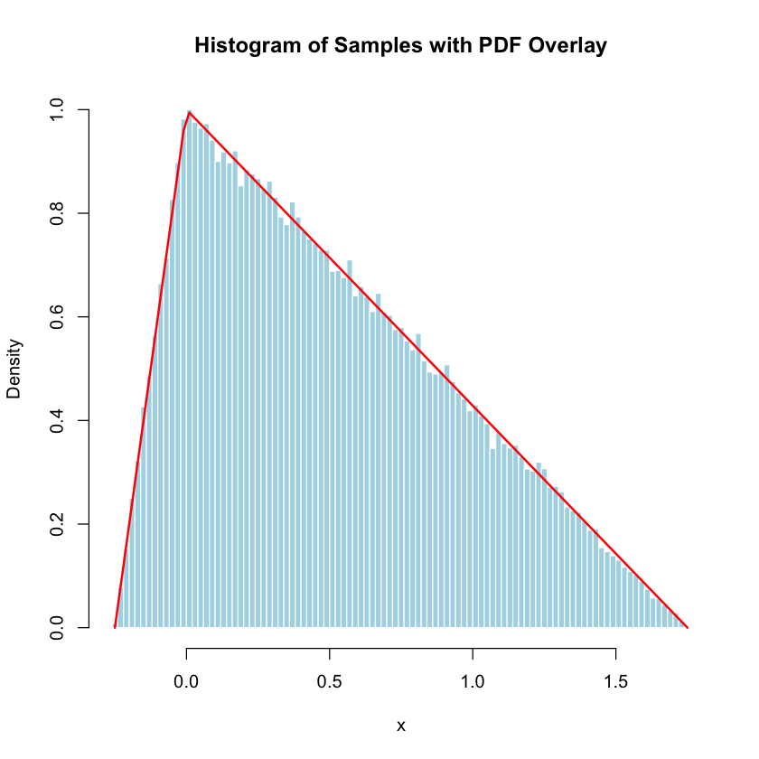

```r
# 1. Generate random samples
samples <- samplingHelper(99999)

# 2. Plot histogram
hist(samples, breaks=100, freq=FALSE, col="lightblue",
     main="Histogram of Samples with PDF Overlay",
     xlab="x", border="white")

# 3. Theoretical PDF for overlay
fx <- function(x) {
  y <- numeric(length(x))
  idx1 <- x >= -0.25 & x < 0
  y[idx1] <- 4 * x[idx1] + 1
  idx2 <- x >= 0 & x < 1.75
  y[idx2] <- -4/7 * x[idx2] + 1
  return(y)
}

curve(fx, from=-0.25, to=1.75, add=TRUE, col="red", lwd=2)
```

### (d)

### Detailed Summary and Justification of the Sampling Method

The sampling method employed is based on the inverse transform technique, which utilizes the quantile function to generate samples from the target distribution.

1. **Derivation of Quantile Function:**
   Starting from the given probability density function ( f(x) ), the cumulative distribution function (CDF) ( F(x) ) is derived by integrating ( f(x) ) piecewise. Subsequently, the inverse CDF or quantile function ( Q(p) ) is obtained by solving ( F(x) = p ) for ( x ). The quantile function has the form: $$ Q(p) = \begin{cases} \frac{-1 + \sqrt{8p}}{4}, & 0 \leq p \leq \frac{1}{8} \\[2em] \frac{7}{4}\left(1 - \sqrt{\frac{8}{7}(1-p)}\right), & \frac{1}{8} < p \leq 1 \end{cases} $$
2. **Generation of Uniform Random Variables:**  
   ( n ) independent uniform random variables ( p ) are generated from the uniform distribution on [0, 1].
3. **Transformation Using Quantile Function:**  
   Each uniform variable ( p ) is transformed to a value ( x = Q(p) ), where the appropriate form of ( Q(p) ) is selected based on the value of ( p ).

**Justification:**  
The quantile function ( Q(p) ) gives the value below which a proportion ( p ) of data falls under the distribution ( f(x) ). Generating uniform random numbers ( p ) over [0, 1] ensures that all cumulative probabilities are equally likely. By transforming these according to ( Q(p) ), samples are produced that correctly represent the distribution of ( f(x) ). This method leverages the one-to-one relationship between the uniform distribution and any continuous distribution via their CDFs and provides an exact and efficient sampling technique. It is a standard approach widely adopted in simulation and Monte Carlo methods when the quantile function can be explicitly computed.